# Assignment 2

Deconstruct, Reconstruct Web Report

Michael Teixeira (S4133975)

## Deconstruct

### Original

The original data visualisation selected for the assignment was as follows:

[figure not shown]

*Charting the 20 Top Growing U.S. Careers Based on Real Salary Projections.*

### Objective and Audience

The objective and audience of the original data visualisation chosen can be summarised as follows:

**Objective**

To visualize and compare both the growth rate and salary changes for the fastest-growing occupations in the United States from 2019 to 2029, highlighting which jobs offer both high growth potential and strong compensation.

**Audience**

Career counselors, job seekers, education planners, and workforce development professionals who need to understand emerging job market trends and make informed decisions about career paths or training programs.

### Critique

The visualisation chosen had the following three main issues:

- **Visual Complexity:** The circular/radial layout, while visually interesting, makes it difficult to compare values across occupations. The curved text and varying angles make it challenging to read occupation titles and compare growth percentages accurately.
- **Data Density Issues:** The visualization attempts to show too much information in a confined space, leading to overcrowded labels and potentially confusing overlaps between the salary figures and growth rates. The small icons, while adding visual interest, don’t contribute meaningful information and add to the visual clutter.
- **Poor Use of Length Encoding:** The radial layout distorts the perception of the differences between values because the human eye is better at comparing lengths when they’re aligned in parallel rather than at different angles. This makes it particularly difficult to compare salaries and growth rates across different occupations.

## Reconstruct

### Code

The following code was used to fix the issues identified in the original.

```r
library(ggplot2)
library(dplyr)
library(tidyr)
library(scales)

# Create dataframe with the occupation data
occupations_data <- data.frame(
  occupation = c(
    "Wind turbine service technicians" = "Wind Turbine Tech.",
    "Solar photovoltaic installers" = "Solar PV Installers",
    "Nurse practitioners" = "Nurse Practitioners",
    "Data scientists" = "Data Scientists",
    "Information security analysts" = "Info. Security Analysts",
    "Medical and health services managers" = "Medical Services Mgrs.",
    "Physician assistants" = "Physician Assistants",
    "Computer and information research scientists" = "Computer Research Sci.",
    "Physical therapist assistants" = "Physical Therapy Asst.",
    "Operations research analysts" = "Operations Analysts",
    "Occupational therapy assistants" = "Occupational Therapy Asst.",
    "Actuaries" = "Actuaries",
    "Financial examiners" = "Financial Examiners",
    "Home health and personal care aides" = "Home Health Aides",
    "Veterinary assistants and laboratory animal caretakers" = "Vet. Lab Assistants",
    "Veterinary technologists and technicians" = "Vet. Technologists",
    "Logisticians" = "Logisticians",
    "Veterinarians" = "Veterinarians",
    "Substance abuse, behavioral disorder, and mental health counselors" = "Mental Health Counselors",
    "Epidemiologists" = "Epidemiologists"
  ),
  growth_rate = c(60, 48, 46, 36, 33, 29, 28, 26, 25, 23, 22, 22, 21, 21, 19, 19, 19, 19, 19, 19),
  current_pay = c(61770, 48800, 126260, 108020, 120360, 110680, 130020, 145080, 64080, 83640, 67010, 120000, 84200, 33530, 36440, 43740, 79400, 119100, 53710, 81390)
)

# Calculate projected pay and format currency values
occupations_data <- occupations_data %>%
  mutate(
    projected_pay = current_pay * (1 + growth_rate / 100),
    current_pay_label = paste0("$", comma(round(current_pay/1000, 1)), "K"),
    projected_pay_label = paste0("$", comma(round(projected_pay/1000, 1)), "K")
  )

# Create the visualization
p1 <- ggplot(occupations_data, aes(x = reorder(occupation, -growth_rate))) +
  geom_segment(aes(y = current_pay, yend = projected_pay, xend = occupation, color = "Growth Projection"),
               size = 0.8) +

  geom_point(aes(y = current_pay, color = "Current Pay"), size = 4) +
  geom_point(aes(y = projected_pay, color = "Projected Pay"), size = 4) +

  geom_text(aes(y = current_pay,
                label = sprintf("$%.1fK", current_pay / 1000)),
            hjust = 1.5, size = 3, color = "#0072B2") +

  geom_text(aes(y = projected_pay,
                label = sprintf("$%.1fK", projected_pay / 1000)),
            hjust = -0.5, size = 3, color = "#009E73") +

  geom_text(aes(y = max(current_pay, projected_pay) * 1.25,
                label = paste0(growth_rate, "%")),
            hjust = -0.2, size = 3.5, color = "gray40") +

  # scale_y_continuous to expand the axis
  scale_y_continuous(
    limits = c(0, max(occupations_data$projected_pay) * 1.3),
    breaks = seq(0, 200000, 50000),
    labels = function(x) paste0("$", x/1000, "K"),
    expand = expansion(mult = c(0.04, 0.1))
  ) +

  coord_flip() +

  labs(title = "Top U.S. Jobs by Projected Salary and Growth Rate (2023-2033)",
       subtitle = "Median Salary, Projected Salary, and Growth Rate for High-Demand Roles",
       x = "",
       y = "Annual Pay (Thousands of USD)",
       caption = "Data source: U.S. Bureau of Labor Statistics") +

  theme_minimal() +
  theme(
    plot.title = element_text(size = 14, face = "bold", margin = margin(t = 20, b = 10), hjust = 0.5),
    plot.subtitle = element_text(size = 12, margin = margin(b = 10), hjust = 0.5),
    axis.text.y = element_text(size = 10, color = "gray20", margin = margin(r = 5)),
    axis.text.x = element_text(size = 9, margin = margin(t = 0, b = 0)),
    panel.grid.major.y = element_blank(),
    panel.grid.minor = element_blank(),
    plot.margin = margin(t = 0, r = 70, b = 0, l = 0),
    plot.caption = element_text(color = "gray50", size = 9, hjust = 0.5),
    plot.background = element_rect(fill = "white", color = NA),
    panel.spacing.y = unit(1.5, "cm"),
    legend.position = "bottom"
  ) +

  scale_x_discrete(expand = expansion(add = c(0.5, 0.5))) +

  scale_color_manual(values = c("Current Pay" = "#0072B2", "Projected Pay" = "#009E73", "Growth Projection" = "gray70"),
                     name = "")
```

### Reconstruction

The following plot fixes the main issues in the original.

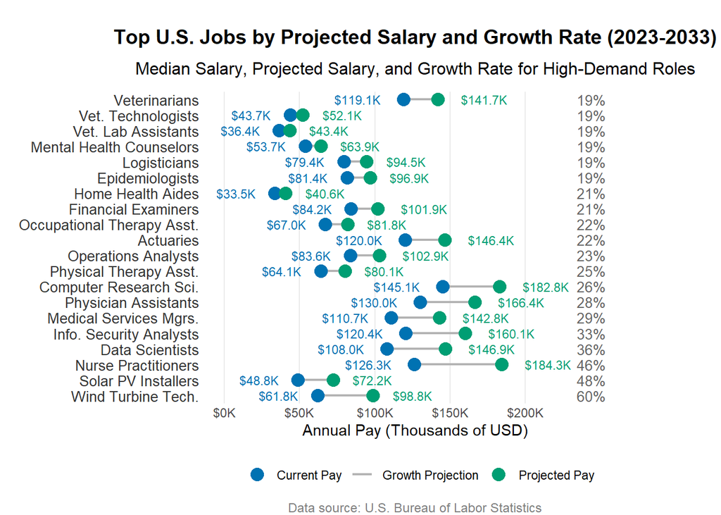

## References

The reference to the original data visualisation choose, the data source(s) used for the reconstruction and any other sources used for this assignment are as follows:

- HowMuch.net. (2019). *Fastest Growing Occupations in the U.S.* Retrieved November 8, 2024, from HowMuch website: https://howmuch.net/articles/fastest-growing-occupations-in-the-US
- U.S. Bureau of Labor Statistics. (2023). *Fastest Growing Occupations.* Retrieved November 8, 2024, from U.S. Bureau of Labor Statistics website: https://www.bls.gov/ooh/fastest-growing.htm